# EAE127_P1_AUNG_EPHRAIM

2.2 Inviscid vs Viscous Flow Comparison

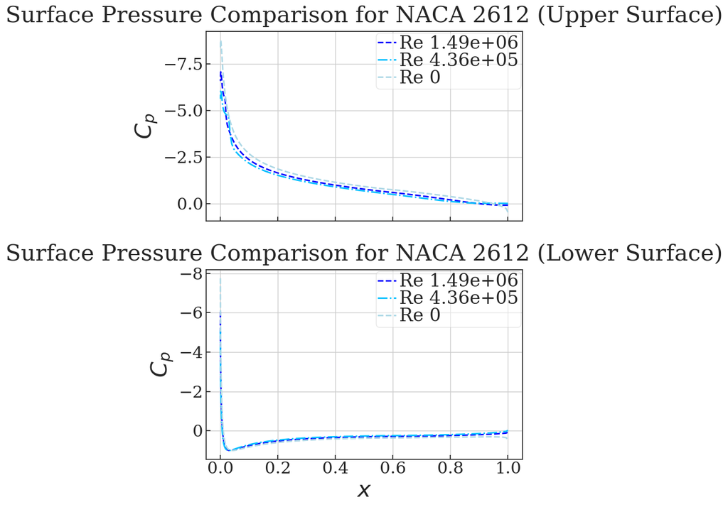

```python
# Surface Pressure Comparison
# For NACA 2612
# Import Data


base_path = 'C:\\Users\\ephra\\OneDrive\\Desktop\\PythonScripts\\EAE127\\.git\\Data\\naca2612'

def load_cp_data(filename):
    return np.loadtxt(filename, skiprows=3, unpack=True, delimiter=None, usecols=(0, 2))

# Re= 1490345.149
x1, Cp1 = load_cp_data(os.path.join(base_path, 'naca2612_surfCP_Re1.49e+06a12.0.dat'))
x1u, x1l = x1[:(len(x1)//2)], x1[(len(x1)//2):]
Cp1u, Cp1l = Cp1[:(len(Cp1)//2)], Cp1[(len(Cp1)//2):]

# Re= 436034.9854
x2, Cp2 = load_cp_data(os.path.join(base_path, 'naca2612_surfCP_Re4.36e+05a12.0.dat'))
x2u, x2l = x2[:(len(x2)//2)], x2[(len(x2)//2):]
Cp2u, Cp2l = Cp2[:(len(Cp2)//2)], Cp2[(len(Cp2)//2):]

# Re= 0
x3, Cp3 = load_cp_data(os.path.join(base_path, 'naca2612_surfCP_Re0.00e+00a12.0.dat'))
x3u, x3l = x3[:(len(x3)//2)], x3[(len(x3)//2):]
Cp3u, Cp3l = Cp3[:(len(Cp3)//2)], Cp3[(len(Cp3)//2):]

# Create Subplots
fig, (ax1, ax2) = plt.subplots(2, 1, figsize=(8, 10), sharex=True)

# Upper Surface Plot
ax1.set_title('Surface Pressure Comparison for NACA 2612 (Upper Surface)')
ax1.set_ylabel("$C_p$")

ax1.plot(x1u, Cp1u, label='Re 1.49e+06', linewidth=2, linestyle='--', color='blue')
ax1.plot(x2u, Cp2u, label='Re 4.36e+05', linewidth=2, linestyle='-.', color='deepskyblue')
ax1.plot(x3u, Cp3u, label='Re 0', linewidth=2, linestyle='--', color='lightblue')

ax1.invert_yaxis()  # Invert y-axis for Cp
ax1.grid(True)
ax1.legend(loc='best')

# Lower Surface Plot
ax2.set_title('Surface Pressure Comparison for NACA 2612 (Lower Surface)')
ax2.set_xlabel("$x$")
ax2.set_ylabel("$C_p$")

ax2.plot(x1l, Cp1l, label='Re 1.49e+06', linewidth=2, linestyle='--', color='blue')
ax2.plot(x2l, Cp2l, label='Re 4.36e+05', linewidth=2, linestyle='-.', color='deepskyblue')
ax2.plot(x3l, Cp3l, label='Re 0', linewidth=2, linestyle='--', color='lightblue')

ax2.invert_yaxis()  # Invert y-axis for Cp
ax2.grid(True)
ax2.legend(loc='best')

# Display plots
plt.tight_layout()
plt.show()
```

The pressure distributions for the NACA 2612 seem to be nearly identical accross the upper and lower surfaces of the airfoil. I do not see any that would be expected from a change of Reynolds number that is 6 orders of magnitude. I feel that the change is smaller than I was expecting.

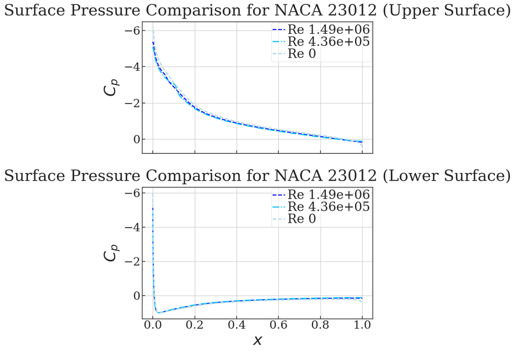

```python
# Surface Pressure Comparison
# For NACA 23012
# Import Data


base_path = 'C:\\Users\\ephra\\OneDrive\\Desktop\\PythonScripts\\EAE127\\.git\\Data\\naca23012'

def load_cp_data(filename):
    return np.loadtxt(filename, skiprows=3, unpack=True, delimiter=None, usecols=(0, 2))

# Re= 1490345.149
x1, Cp1 = load_cp_data(os.path.join(base_path, 'naca23012_surfCP_Re1.49e+06a12.0.dat'))
x1u, x1l = x1[:(len(x1)//2)], x1[(len(x1)//2):]
Cp1u, Cp1l = Cp1[:(len(Cp1)//2)], Cp1[(len(Cp1)//2):]

# Re= 436034.9854
x2, Cp2 = load_cp_data(os.path.join(base_path, 'naca23012_surfCP_Re4.36e+05a12.0.dat'))
x2u, x2l = x2[:(len(x2)//2)], x2[(len(x2)//2):]
Cp2u, Cp2l = Cp2[:(len(Cp2)//2)], Cp2[(len(Cp2)//2):]

# Re= 0
x3, Cp3 = load_cp_data(os.path.join(base_path, 'naca23012_surfCP_Re0.00e+00a12.0.dat'))
x3u, x3l = x3[:(len(x3)//2)], x3[(len(x3)//2):]
Cp3u, Cp3l = Cp3[:(len(Cp3)//2)], Cp3[(len(Cp3)//2):]

# Create Subplots
fig, (ax1, ax2) = plt.subplots(2, 1, figsize=(8, 10), sharex=True)

# Upper Surface Plot
ax1.set_title('Surface Pressure Comparison for NACA 23012 (Upper Surface)')
ax1.set_ylabel("$C_p$")

ax1.plot(x1u, Cp1u, label='Re 1.49e+06', linewidth=2, linestyle='--', color='blue')
ax1.plot(x2u, Cp2u, label='Re 4.36e+05', linewidth=2, linestyle='-.', color='deepskyblue')
ax1.plot(x3u, Cp3u, label='Re 0', linewidth=2, linestyle='--', color='lightblue')

ax1.invert_yaxis()  # Invert y-axis for Cp
ax1.grid(True)
ax1.legend(loc='best')

# Lower Surface Plot
ax2.set_title('Surface Pressure Comparison for NACA 23012 (Lower Surface)')
ax2.set_xlabel("$x$")
ax2.set_ylabel("$C_p$")

ax2.plot(x1l, Cp1l, label='Re 1.49e+06', linewidth=2, linestyle='--', color='blue')
ax2.plot(x2l, Cp2l, label='Re 4.36e+05', linewidth=2, linestyle='-.', color='deepskyblue')
ax2.plot(x3l, Cp3l, label='Re 0', linewidth=2, linestyle='--', color='lightblue')

ax2.invert_yaxis()  # Invert y-axis for Cp
ax2.grid(True)
ax2.legend(loc='best')

# Display plots
plt.tight_layout()
plt.show()
```

The pressure distributions for the NACA 23012 seem to be nearly identical accross the upper and lower surfaces of the airfoil. I do not see any that would be expected from a change of Reynolds number that is 6 orders of magnitude. I feel that the change is smaller than I was expecting.

2.3 Airfoil and Drag Polars

```python
import pandas as pd
import sys
import pyxfoil

foil = '23012'
naca = True
Re   = 436034.9854
alfs = np.linspace(-12, 12, 50) #Angles of Attack
print("Running XFOIL/pyxfoil and saving data in 'Data/naca0012' folder...\n")
pyxfoil.GetPolar(foil, naca, alfs, Re, SaveCP=True, quiet=True)


foil = '2612'
naca = True
Re   = 436034.9854
alfs = np.linspace(-12, 12, 50) #Angles of Attack
print("Running XFOIL/pyxfoil and saving data in 'Data/naca0012' folder...\n")
pyxfoil.GetPolar(foil, naca, alfs, Re, SaveCP=True, quiet=True)
```

```
Running XFOIL/pyxfoil and saving data in 'Data/naca0012' folder...

Running XFOIL/pyxfoil and saving data in 'Data/naca0012' folder...
```

```
<pyxfoil.Xfoil at 0x23e19a494f0>
```

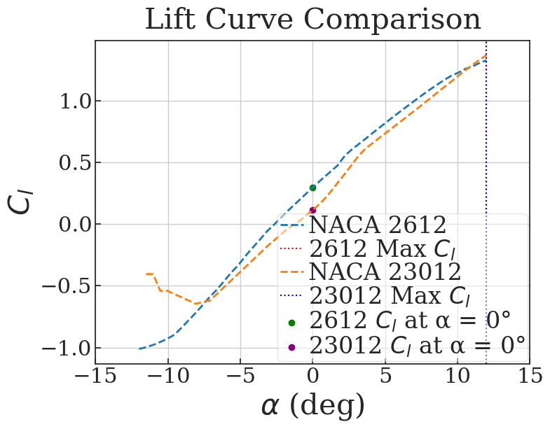

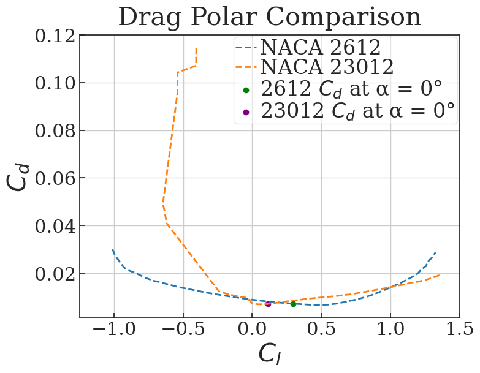

```
NACA 2612 - Maximum C_l: 1.3260 at α = 12.00°
NACA 23012 - Maximum C_l: 1.3686 at α = 12.00°
NACA 2612 - Stall angle: 12.00°
NACA 23012 - Stall angle: 12.00°
NACA 2612 - Zero α : C_l = 0.2960, C_d = 0.0072
NACA 23012 - Zero α : C_l = 0.1142, C_d = 0.0071
```

```python
#Re = Case 1


filename_2612 = 'C:\\Users\\ephra\\OneDrive\\Desktop\\PythonScripts\\EAE127\\.git\\Data\\naca2612\\naca2612_polar_Re4.36e+05a-12.0-12.0.dat'
Alpha4, Cl4, Cd4 = np.loadtxt(filename_2612, skiprows=12, unpack=True, usecols=(0, 1, 2))
filename_23012 = 'C:\\Users\\ephra\\OneDrive\\Desktop\\PythonScripts\\EAE127\\.git\\Data\\naca23012\\naca23012_polar_Re4.36e+05a-12.0-12.0.dat'
Alpha5, Cl5, Cd5 = np.loadtxt(filename_23012, skiprows=12, unpack=True, usecols=(0, 1, 2))

# Find maximum and minimum Cl values for NACA 2612
max_Cl4_index = np.argmax(Cl4)
max_Cl4 = Cl4[max_Cl4_index]
alphamaxCl4 = Alpha4[max_Cl4_index]

min_Cl4_index = np.argmin(Cl4)
min_Cl4 = Cl4[min_Cl4_index]
alphaminCl4 = Alpha4[min_Cl4_index]

# Find maximum and minimum Cl values for NACA 23012
max_Cl5_index = np.argmax(Cl5)
max_Cl5 = Cl5[max_Cl5_index]
alphamaxCl5 = Alpha5[max_Cl5_index]

min_Cl5_index = np.argmin(Cl5)
min_Cl5 = Cl5[min_Cl5_index]
alphaminCl5 = Alpha5[min_Cl5_index]

# Stall angle of attack = maximum lift coefficient
stall_angle_Cl4 = alphamaxCl4
stall_angle_Cl5 = alphamaxCl5

# Linear interpolation to find the y-intercept (Cl and Cd at alpha = 0)
alphazeroCl4 = np.interp(0, Alpha4, Cl4)
alphazeroCd4 = np.interp(0, Alpha4, Cd4)

alphazeroCl5 = np.interp(0, Alpha5, Cl5)
alphazeroCd5 = np.interp(0, Alpha5, Cd5)

# Plot Lift Curves
plt.figure(figsize=(8, 6))
plt.title('Lift Curve Comparison')
plt.xlabel("$\\alpha$ (deg)")
plt.ylabel("$C_l$")

plt.plot(Alpha4, Cl4, label='NACA 2612', linewidth=2, linestyle='--')
plt.axvline(alphamaxCl4, color='red', linestyle=':', label=f'2612 Max $C_l$')

plt.plot(Alpha5, Cl5, label='NACA 23012', linewidth=2, linestyle='--')
plt.axvline(alphamaxCl5, color='blue', linestyle=':', label=f'23012 Max $C_l$')

# Mark interpolated zero angle of attack for both airfoils
plt.scatter(0, alphazeroCl4, color='green', label=f'2612 $C_l$ at α = 0°')
plt.scatter(0, alphazeroCl5, color='purple', label=f'23012 $C_l$ at α = 0°')

plt.grid(True)
plt.xlim([-15, 15])
plt.legend(loc='best')
plt.show()

# Plot Drag Polars
plt.figure(figsize=(8, 6))
plt.title('Drag Polar Comparison')
plt.xlabel("$C_l$")
plt.ylabel("$C_d$")

plt.plot(Cl4, Cd4, label='NACA 2612', linewidth=2, linestyle='--')
plt.plot(Cl5, Cd5, label='NACA 23012', linewidth=2, linestyle='--')

# Mark interpolated zero angle of attack drag for both airfoils
plt.scatter(alphazeroCl4, alphazeroCd4, color='green', label=f'2612 $C_d$ at α = 0°')
plt.scatter(alphazeroCl5, alphazeroCd5, color='purple', label=f'23012 $C_d$ at α = 0°')

plt.grid(True)
plt.xlim([-1.25, 1.5])
plt.legend(loc='best')
plt.show()

# Print key information
print(f"NACA 2612 - Maximum C_l: {max_Cl4:.4f} at α = {alphamaxCl4:.2f}°")
print(f"NACA 23012 - Maximum C_l: {max_Cl5:.4f} at α = {alphamaxCl5:.2f}°")
print(f"NACA 2612 - Stall angle: {stall_angle_Cl4:.2f}°")
print(f"NACA 23012 - Stall angle: {stall_angle_Cl5:.2f}°")
print(f"NACA 2612 - Zero α : C_l = {alphazeroCl4:.4f}, C_d = {alphazeroCd4:.4f}")
print(f"NACA 23012 - Zero α : C_l = {alphazeroCl5:.4f}, C_d = {alphazeroCd5:.4f}")
```

2.4 Force and Moment Integration

```python
import numpy as np
import matplotlib.pyplot as plt
import os

# Load data from file
base_path3 = 'C:\\Users\\ephra\\OneDrive\\Desktop\\PythonScripts\\EAE127\\.git\\Data\\naca23012'

def load_cp_data(filename):
    return np.loadtxt(filename, skiprows=12, unpack=True, delimiter=None, usecols=(0, 1, 2))

def calculate_aerodynamic_properties(filename):
    # Load data
    x, y, Cp = load_cp_data(filename)

    # Chord length
    c = 1.0

    # Calculate lower and upper surface pressure coefficients
    Cp_l = Cp[:len(Cp)//2]   # Lower surface (first half)
    Cp_u = Cp[len(Cp)//2:]   # Upper surface (second half)

    # Ensure both Cp_l and Cp_u are the same length
    min_length = min(len(Cp_l), len(Cp_u))
    Cp_l = Cp_l[:min_length]
    Cp_u = Cp_u[:min_length]
    x = x[:min_length]  # Adjust x to match the new length
    y_l = y[:min_length]  # Lower surface y values
    y_u = y[len(y)//2:len(y)//2 + min_length]  # Upper surface y values

    # Integrate for Cn
    Cn = (1 / c) * np.trapz(Cp_l - Cp_u, x)

    # Calculate surface slopes using finite differences
    dz_dx_u = np.gradient(y_u, x)  # Upper surface
    dz_dx_l = np.gradient(y_l, x)  # Lower surface

    # Calculate Ca
    Ca = (1 / c) * np.trapz(dz_dx_u * Cp_u - dz_dx_l * Cp_l, x)

    # Calculate Cm,LE
    Cm_LE = (1 / c) * 0.5 * np.trapz(Cp_u - Cp_l, x)

    # Calculate lift coefficient Cl and drag coefficient Cd
    alpha = np.radians(12.0)  # Convert angle to radians
    Cl = Cn * np.cos(alpha) - Ca * np.sin(alpha)
    Cd = Cn * np.sin(alpha) + Ca * np.cos(alpha)

    # Moment about the quarter chord
    Cm_c = Cm_LE + Cl * (c / 4)

    return Cl, Cd, Cm_c, x, Cp

# File paths for three Reynolds numbers
filenames = [
    os.path.join(base_path3, 'naca23012_surfCP_Re1.49e+06a12.0.dat'),
    os.path.join(base_path3, 'naca23012_surfCP_Re4.36e+05a12.0.dat'),
    os.path.join(base_path3, 'naca23012_surfCP_Re0.00e+00a12.0.dat'),
]

# XFOIL results manual input
xf_results = [
    (1.4203, 0.01436, -0.0059),  # Re1.49e+06
    (1.3686, 0.01945, 0.0022),   # Re4.36e+05
    (1.5747, 0.0, -0.0311),      # Re0.00e+00
]

# Process each dataset and store results
results = []
for i, filename in enumerate(filenames):
    Cl, Cd, Cm_c, x, Cp = calculate_aerodynamic_properties(filename)
    results.append((Cl, Cd, Cm_c, x, Cp, xf_results[i]))

# Print results
print(f"NACA 23012 at α = 12°")
print("Re\t\tCl\t\tCd\t\tCm")
for i, (Cl, Cd, Cm_c, x, Cp, (Cl_xf, Cd_xf, Cm_xf)) in enumerate(results):
    print(f"Re{i+1}\t{Cl_xf:.5f}\t{Cd_xf:.5f}\t{Cm_xf:.5f}")
    print(f"Integration\t{Cl:.5f}\t{Cd:.5f}\t{Cm_c:.5f}")
```

```
NACA 23012 at α = 12°
Re		Cl		Cd		Cm
Re1	1.42030	0.01436	-0.00590
Integration	1.40337	-0.00253	-0.33525
Re2	1.36860	0.01945	0.00220
Integration	1.37307	-0.00168	-0.32809
Re3	1.57470	0.00000	-0.03110
Integration	1.48796	-0.00765	-0.35494
```